# Update

## Figures

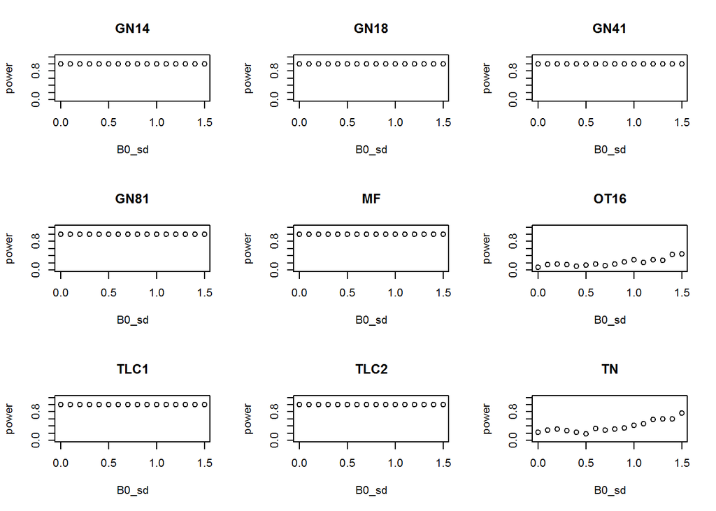

Figure 1. Power of detecting a significant CPUE trend based on 100 replicates for each level of B0_sd with mean catchability set to 0.00001.

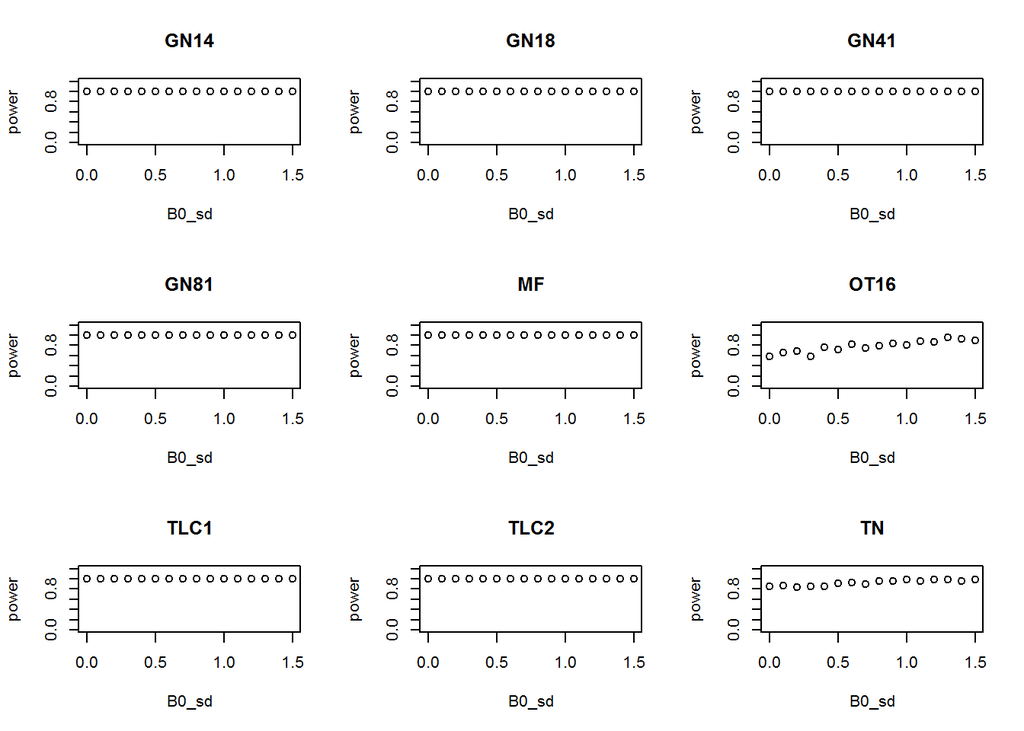

Figure 2. Power of detecting a significant CPUE trend based on 100 replicates for each level of B0_sd with mean catchability set to 0.00004.

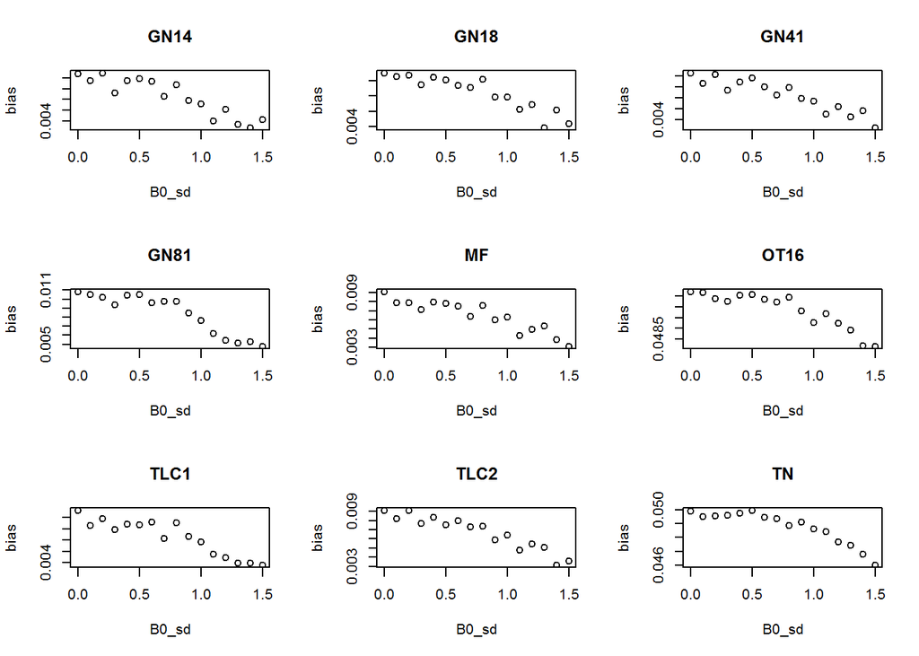

Figure 3. CPUE trend bias from 100 replicates for each level of B0_sd with mean catchability set to 0.00001.

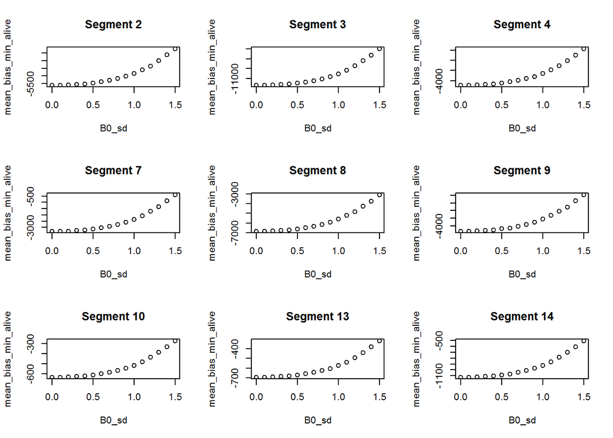

Figure 4. Minimum Alive bias from 100 replicates for each level of B0_sd with mean catchability set to 0.00001.

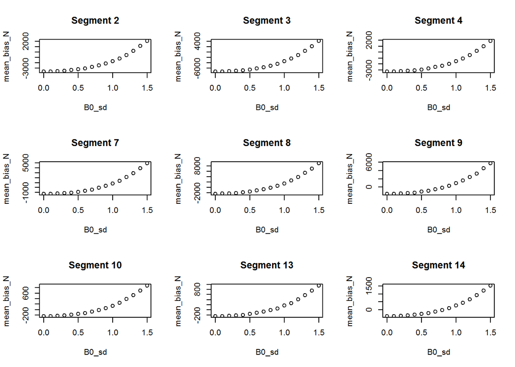

Figure 5. Catch abundance bias from 100 replicates for each level of B0_sd with mean catchability set to 0.00001.

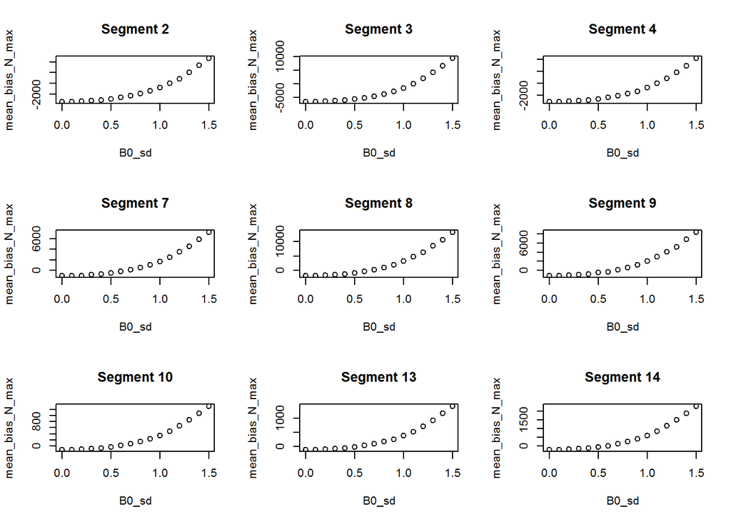

Figure 6. Upper catch abundance bias from 100 replicates for each level of B0_sd with mean catchability set to 0.00001.

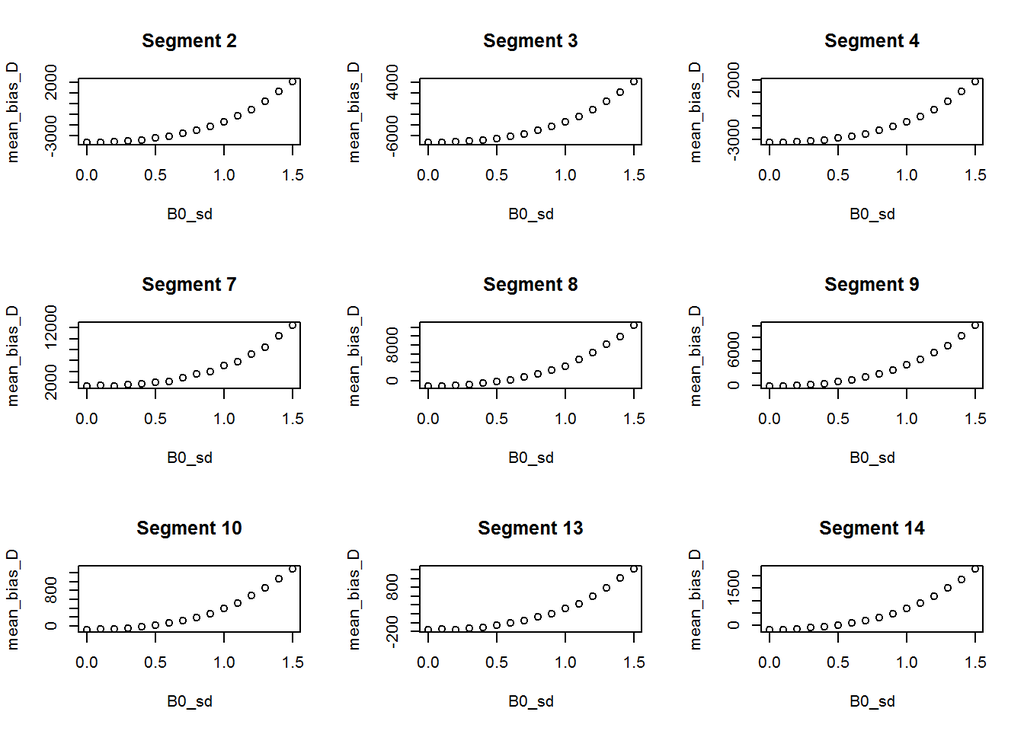

Figure 7. Catch density abundance bias from 100 replicates for each level of B0_sd with mean catchability set to 0.00001.

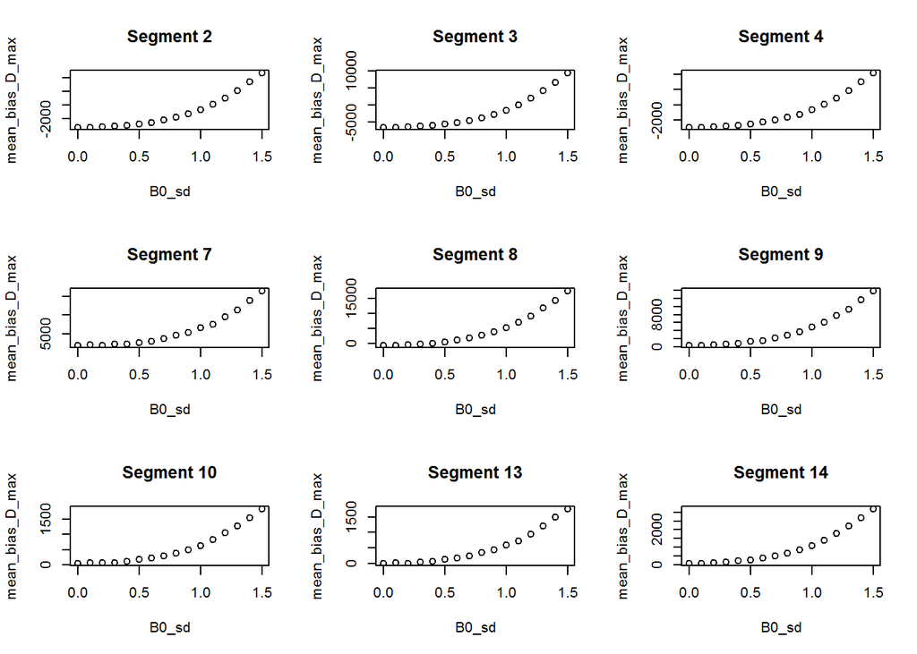

Figure 8. Upper catch density abundance bias from 100 replicates for each level of B0_sd with mean catchability set to 0.00001.

## Tables

Table 1. Summary of trend data of 100 replicates by gear for B0_sd=0.5 and mean q=0.00001.

| Gear | Mean Trend | Mean SE | Max SE | Mean P-value | Max P-value | Mean Flag Count | Power | Bias | Mean q | B0 SD |
| --- | --- | --- | --- | --- | --- | --- | --- | --- | --- | --- |
| GN14 | -0.0440063 | 0.0046657 | 0.0058201 | 0.0000000 | 0.0000002 | 0 | 1.00 | 0.0079133 | 1e-05 | 0.5 |
| GN18 | -0.0418619 | 0.0061305 | 0.0081228 | 0.0000094 | 0.0005589 | 0 | 1.00 | 0.0100576 | 1e-05 | 0.5 |
| GN41 | -0.0441005 | 0.0046553 | 0.0057438 | 0.0000000 | 0.0000000 | 0 | 1.00 | 0.0078191 | 1e-05 | 0.5 |
| GN81 | -0.0414445 | 0.0061146 | 0.0079359 | 0.0000065 | 0.0002999 | 0 | 1.00 | 0.0104750 | 1e-05 | 0.5 |
| MF | -0.0441371 | 0.0046614 | 0.0057701 | 0.0000000 | 0.0000000 | 0 | 1.00 | 0.0077825 | 1e-05 | 0.5 |
| OT16 | -0.0013727 | 0.0016652 | 0.0020463 | 0.4119135 | 0.9991016 | 0 | 0.14 | 0.0505469 | 1e-05 | 0.5 |
| TLC1 | -0.0445724 | 0.0046831 | 0.0058679 | 0.0000000 | 0.0000000 | 0 | 1.00 | 0.0073472 | 1e-05 | 0.5 |
| TLC2 | -0.0443839 | 0.0046338 | 0.0058908 | 0.0000000 | 0.0000001 | 0 | 1.00 | 0.0075357 | 1e-05 | 0.5 |
| TN | -0.0019624 | 0.0017121 | 0.0020203 | 0.3242264 | 0.9521492 | 0 | 0.18 | 0.0499572 | 1e-05 | 0.5 |

Table 2. Summary of abundance estimates of 100 replicates by gear for B0_sd=0.5 and mean q=0.00001.

| Segment | Minimum Alive Mean | Minimum Alive SD | Minimum Alive Mean Bias | Mean Abundance_N | Abundance_N SD | Abundance_N Mean Bias | Mean q | B0 SD |
| --- | --- | --- | --- | --- | --- | --- | --- | --- |
| 2 | 1119.146 | 183.55694 | -5473.854 | 3345.1711 | 563.3734 | -3247.8289 | 1e-05 | 0.5 |
| 3 | 1726.676 | 278.54922 | -11474.624 | 6685.9144 | 1109.7441 | -6515.3856 | 1e-05 | 0.5 |
| 4 | 1650.937 | 323.12332 | -4243.163 | 2988.1313 | 594.2030 | -2905.9687 | 1e-05 | 0.5 |
| 7 | 1424.474 | 271.51453 | -3134.426 | 3679.0616 | 714.3421 | -879.8384 | 1e-05 | 0.5 |
| 8 | 1843.864 | 329.57999 | -6618.736 | 6838.1081 | 1247.8242 | -1624.4919 | 1e-05 | 0.5 |
| 9 | 1215.163 | 310.44153 | -4201.037 | 4370.8681 | 1158.9839 | -1045.3319 | 1e-05 | 0.5 |
| 10 | 203.859 | 40.03038 | -612.741 | 663.3536 | 138.9078 | -153.2464 | 1e-05 | 0.5 |
| 13 | 211.391 | 40.81473 | -670.709 | 718.6636 | 149.2674 | -163.4364 | 1e-05 | 0.5 |
| 14 | 341.520 | 62.10893 | -1088.980 | 1156.4107 | 224.0256 | -274.0893 | 1e-05 | 0.5 |

| Segment | Mean Abundance_Nmax | Abundance_Nmax SD | Abundance_Nmax Mean Bias | Mean Abundance_D | Abundance_D SD | Abundance_D Mean Bias | Mean q | B0 SD |
| --- | --- | --- | --- | --- | --- | --- | --- | --- |
| 2 | 3730.4867 | 611.8565 | -2862.51333 | 3360.9393 | 506.9407 | -3232.06072 | 1e-05 | 0.5 |
| 3 | 7482.2627 | 1207.0466 | -5719.03733 | 6700.7537 | 989.4439 | -6500.54634 | 1e-05 | 0.5 |
| 4 | 3301.8740 | 646.2466 | -2592.22600 | 3010.7779 | 435.6400 | -2883.32212 | 1e-05 | 0.5 |
| 7 | 4036.0097 | 769.2912 | -522.89033 | 6526.2128 | 2914.8391 | 1967.31285 | 1e-05 | 0.5 |
| 8 | 7498.3803 | 1340.2920 | -964.21973 | 8140.0348 | 1780.0964 | -322.56520 | 1e-05 | 0.5 |
| 9 | 4875.9135 | 1244.4075 | -540.28653 | 6041.7830 | 2002.6516 | 625.58299 | 1e-05 | 0.5 |
| 10 | 795.0501 | 156.1185 | -21.54990 | 834.9066 | 208.9576 | 18.30665 | 1e-05 | 0.5 |
| 13 | 864.7814 | 166.9693 | -17.31864 | 830.2058 | 191.6847 | -51.89422 | 1e-05 | 0.5 |
| 14 | 1366.0800 | 248.4357 | -64.42000 | 1445.7396 | 290.1783 | 15.23963 | 1e-05 | 0.5 |

| Segment | Mean Abundance_Dmax | Abundance_Dmax SD | Abundance_Dmax Mean Bias | Mean q | B0 SD |
| --- | --- | --- | --- | --- | --- |
| 2 | 3761.003 | 554.9040 | -2831.9971 | 1e-05 | 0.5 |
| 3 | 7524.047 | 1078.2619 | -5677.2526 | 1e-05 | 0.5 |
| 4 | 3350.762 | 477.0694 | -2543.3379 | 1e-05 | 0.5 |
| 7 | 7153.073 | 3175.3807 | 2594.1726 | 1e-05 | 0.5 |
| 8 | 8932.850 | 1921.9129 | 470.2498 | 1e-05 | 0.5 |
| 9 | 6718.878 | 2158.3929 | 1302.6777 | 1e-05 | 0.5 |
| 10 | 1001.443 | 239.7910 | 184.8429 | 1e-05 | 0.5 |
| 13 | 1000.297 | 216.7542 | 118.1971 | 1e-05 | 0.5 |
| 14 | 1711.029 | 326.9219 | 280.5289 | 1e-05 | 0.5 |

[comments powered by Disqus](http://disqus.com)